# Transit

2021-01-05

# TidyTuesday

Join the R4DS Online Learning Community in the weekly #TidyTuesday event! Every week we post a raw dataset, a chart or article related to that dataset, and ask you to explore the data. While the dataset will be “tamed”, it will not always be tidy! As such you might need to apply various R for Data Science techniques to wrangle the data into a true tidy format. The goal of TidyTuesday is to apply your R skills, get feedback, explore other’s work, and connect with the greater #RStats community! As such we encourage everyone of all skills to participate!

```r
library(tidyverse)
library(tidytuesdayR)
library(lubridate)
library(dplyr)
library(tidyr)
#install.packages("countrycode")
```

# Load the weekly Data

Dowload the weekly data and make available in the `tt` object.

```r
# download the data
tt <- tt_load("2021-01-05")
#saving the data as a variable
transit <- tt$'transit_cost'
```

# Readme

Take a look at the readme for the weekly data to get insight on the dataset. This includes a data dictionary, source, and a link to an article on the data.

```r
readme(tt)
print(tt)
```

# Glimpse Data

Take an initial look at the format of the data available.

```r
tt %>%
  map(glimpse)
```

```
## Rows: 544
## Columns: 20
## $ e                <dbl> 7136, 7137, 7138, 7139, 7144, 7145, 7146, 7147, 7152…
## $ country          <chr> "CA", "CA", "CA", "CA", "CA", "NL", "CA", "US", "US"…
## $ city             <chr> "Vancouver", "Toronto", "Toronto", "Toronto", "Toron…
## $ line             <chr> "Broadway", "Vaughan", "Scarborough", "Ontario", "Yo…
## $ start_year       <chr> "2020", "2009", "2020", "2020", "2020", "2003", "202…
## $ end_year         <chr> "2025", "2017", "2030", "2030", "2030", "2018", "202…
## $ rr               <dbl> 0, 0, 0, 0, 0, 0, 0, 0, 0, 0, 0, 0, 0, 0, 0, 0, 0, 0…
## $ length           <dbl> 5.7, 8.6, 7.8, 15.5, 7.4, 9.7, 5.8, 5.1, 4.2, 4.2, 6…
## $ tunnel_per       <chr> "87.72%", "100.00%", "100.00%", "57.00%", "100.00%",…
## $ tunnel           <dbl> 5.0, 8.6, 7.8, 8.8, 7.4, 7.1, 5.8, 5.1, 4.2, 4.2, 6.…
## $ stations         <dbl> 6, 6, 3, 15, 6, 8, 5, 2, 2, 2, 3, 3, 4, 7, 13, 4, 4,…
## $ source1          <chr> "Plan", "Media", "Wiki", "Plan", "Plan", "Wiki", "Me…
## $ cost             <dbl> 2830, 3200, 5500, 8573, 5600, 3100, 4500, 1756, 3600…
## $ currency         <chr> "CAD", "CAD", "CAD", "CAD", "CAD", "EUR", "CAD", "US…
## $ year             <dbl> 2018, 2013, 2018, 2019, 2020, 2009, 2018, 2012, 2023…
## $ ppp_rate         <dbl> 0.840, 0.810, 0.840, 0.840, 0.840, 1.300, 0.840, 1.0…
## $ real_cost        <chr> "2377.2", "2592", "4620", "7201.32", "4704", "4030",…
## $ cost_km_millions <dbl> 417.05263, 301.39535, 592.30769, 464.60129, 635.6756…
## $ source2          <chr> "Media", "Media", "Media", "Plan", "Media", "Media",…
## $ reference        <chr> "https://www.translink.ca/Plans-and-Projects/Rapid-T…
```

```
## $transit_cost
## # A tibble: 544 x 20
##        e country city  line  start_year end_year    rr length tunnel_per tunnel
##    <dbl> <chr>   <chr> <chr> <chr>      <chr>    <dbl>  <dbl> <chr>       <dbl>
##  1  7136 CA      Vanc… Broa… 2020       2025         0    5.7 87.72%        5
##  2  7137 CA      Toro… Vaug… 2009       2017         0    8.6 100.00%       8.6
##  3  7138 CA      Toro… Scar… 2020       2030         0    7.8 100.00%       7.8
##  4  7139 CA      Toro… Onta… 2020       2030         0   15.5 57.00%        8.8
##  5  7144 CA      Toro… Yong… 2020       2030         0    7.4 100.00%       7.4
##  6  7145 NL      Amst… Nort… 2003       2018         0    9.7 73.00%        7.1
##  7  7146 CA      Mont… Blue… 2020       2026         0    5.8 100.00%       5.8
##  8  7147 US      Seat… U-Li… 2009       2016         0    5.1 100.00%       5.1
##  9  7152 US      Los … Purp… 2020       2027         0    4.2 100.00%       4.2
## 10  7153 US      Los … Purp… 2018       2026         0    4.2 100.00%       4.2
## # … with 534 more rows, and 10 more variables: stations <dbl>, source1 <chr>,
## #   cost <dbl>, currency <chr>, year <dbl>, ppp_rate <dbl>, real_cost <chr>,
## #   cost_km_millions <dbl>, source2 <chr>, reference <chr>
```

```r
head(transit)
```

```
## # A tibble: 6 x 20
##       e country city  line  start_year end_year    rr length tunnel_per tunnel
##   <dbl> <chr>   <chr> <chr> <chr>      <chr>    <dbl>  <dbl> <chr>       <dbl>
## 1  7136 CA      Vanc… Broa… 2020       2025         0    5.7 87.72%        5
## 2  7137 CA      Toro… Vaug… 2009       2017         0    8.6 100.00%       8.6
## 3  7138 CA      Toro… Scar… 2020       2030         0    7.8 100.00%       7.8
## 4  7139 CA      Toro… Onta… 2020       2030         0   15.5 57.00%        8.8
## 5  7144 CA      Toro… Yong… 2020       2030         0    7.4 100.00%       7.4
## 6  7145 NL      Amst… Nort… 2003       2018         0    9.7 73.00%        7.1
## # … with 10 more variables: stations <dbl>, source1 <chr>, cost <dbl>,
## #   currency <chr>, year <dbl>, ppp_rate <dbl>, real_cost <chr>,
## #   cost_km_millions <dbl>, source2 <chr>, reference <chr>
```

# Wrangle

Explore the data and process it into a nice format for plotting! Access each dataset by name by using a dollarsign after the `tt` object and then the name of the data set.

```r
# write the data to a csv file
write.csv(transit, "transit_cost.csv", )

transit <- readr::read_csv("transit_cost.csv")  %>%
  mutate(real_cost = as.numeric(real_cost), start_year = as.numeric(start_year)) %>%
  filter(!is.na(line)) # %>%

  # mutate(region = countrycode(country, origin = "ecb", destination = "region")) %>%
  # mutate(region = case_when(country == "UK" ~ "Europe & Central Asia", TRUE ~ region))
```

```r
head(transit)
```

```
## # A tibble: 6 x 21
##      X1     e country city  line  start_year end_year    rr length tunnel_per
##   <dbl> <dbl> <chr>   <chr> <chr>      <dbl> <chr>    <dbl>  <dbl> <chr>
## 1     1  7136 CA      Vanc… Broa…       2020 2025         0    5.7 87.72%
## 2     2  7137 CA      Toro… Vaug…       2009 2017         0    8.6 100.00%
## 3     3  7138 CA      Toro… Scar…       2020 2030         0    7.8 100.00%
## 4     4  7139 CA      Toro… Onta…       2020 2030         0   15.5 57.00%
## 5     5  7144 CA      Toro… Yong…       2020 2030         0    7.4 100.00%
## 6     6  7145 NL      Amst… Nort…       2003 2018         0    9.7 73.00%
## # … with 11 more variables: tunnel <dbl>, stations <dbl>, source1 <chr>,
## #   cost <dbl>, currency <chr>, year <dbl>, ppp_rate <dbl>, real_cost <dbl>,
## #   cost_km_millions <dbl>, source2 <chr>, reference <chr>
```

```r
tail(transit)
```

```
## # A tibble: 6 x 21
##      X1     e country city  line  start_year end_year    rr length tunnel_per
##   <dbl> <dbl> <chr>   <chr> <chr>      <dbl> <chr>    <dbl>  <dbl> <chr>
## 1   532  9507 TR      Ista… M5 P…       2016 2022         0   17.8 100.00%
## 2   533  9508 TR      Ista… M12         2017 2022         0   13   100.00%
## 3   534  9509 TR      Ista… M11 …       2016 2021         0   37.5 100.00%
## 4   535  9510 TR      Ista… M11 …       2019 2022         0   32   100.00%
## 5   536  9459 UZ      Tash… Serg…       2017 2020         0    7.1 0.00%
## 6   537  9460 UZ      Tash… Yunu…       2017 2020         0    2.9 100.00%
## # … with 11 more variables: tunnel <dbl>, stations <dbl>, source1 <chr>,
## #   cost <dbl>, currency <chr>, year <dbl>, ppp_rate <dbl>, real_cost <dbl>,
## #   cost_km_millions <dbl>, source2 <chr>, reference <chr>
```

```r
transit %>%
  group_by(country) %>%
  summarize(mean(real_cost))
```

```
## # A tibble: 56 x 2
##    country `mean(real_cost)`
##  * <chr>               <dbl>
##  1 AE                  6637.
##  2 AR                  4646
##  3 AT                  1352
##  4 AU                  6238.
##  5 BD                 12352.
##  6 BE                  1170
##  7 BG                  1016.
##  8 BH                  4882.
##  9 BR                  3665
## 10 CA                  3283.
## # … with 46 more rows
```

```r
# looking at the average real cost by country
tapply(transit$real_cost, transit$country, mean)
```

```
##        AE        AR        AT        AU        BD        BE        BG        BH
##  6636.667  4646.000  1352.000  6237.600 12351.893  1170.000  1016.295  4882.500
##        BR        CA        CH        CL        CN        CZ        DE        DK
##  3665.000  3282.997   865.232  5015.000  4240.633  1519.040   733.160  3491.400
##        EC        EG        ES        FI        FR        GR        HU        ID
##  3819.000  5784.643  1357.250  1273.870  3868.451  1218.425  3579.840  2934.303
##        IL        IN        IR        IT        JP        KR        KW        MX
##  5038.400  6753.120  4640.000   971.415  2076.532  2384.063 30400.000  4783.390
##        MY        NL        NO        NZ        PA        PE        PH        PK
## 18035.500  4030.000   871.155  2991.663  4330.507 11088.400  8338.950  6039.000
##        PL        PT        QA        RO        RU        SA        SE        SG
##  1340.817   340.600 90000.000  1860.712  5095.583 13545.280  1072.340 19503.500
##        TH        TR        TW        UA        UK        US        UZ        VN
##  5834.779  1891.235  4977.106  2738.318  8441.067  4377.769   667.500  4756.626
```

# Visualize

Using your processed dataset, create your unique visualization.

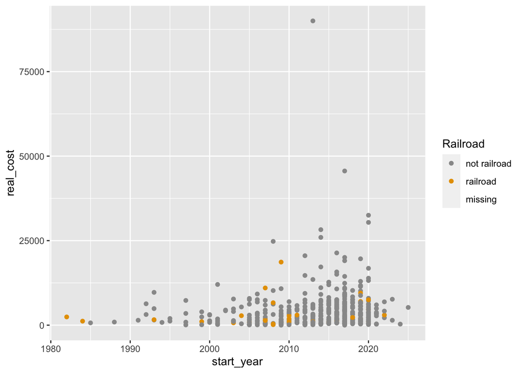

```r
transit %>%
  ggplot(aes(x = start_year, y = real_cost, color = as.factor(rr)) ) +
  geom_point() +
  scale_color_manual(values = c("#999999", "#E69F00", "#569BBD"),
                       name = "Railroad",
                       breaks = c(0, 1, NA),
                       labels = c("not railroad", "railroad", "missing"))
```

```r
# non-railroad vs railroad counts
table(transit$rr)
```

```
##
##   0   1
## 502  34
```

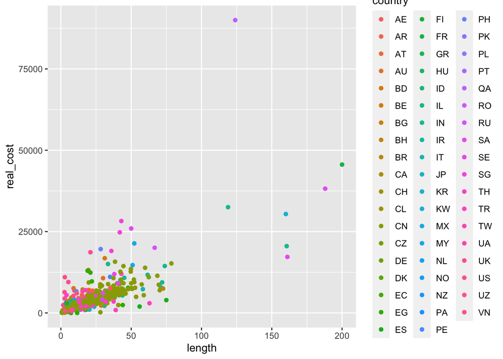

```r
# figure out how to replace 'country' with 'region' by using the 'countrycode' package
transit %>%
  ggplot(aes(x = length, y = real_cost, color = country)) +
  geom_point()
```

```r
# run this once we figure out the conuntrycode package!!!
#transit %>%
  #ggplot(aes(y = real_cost, x = region, color = region)) +
  #geom_boxplot()
```

```r
library(knitr)
#knit('2021_01_05_tidy_tuesday.Rmd', encoding = 'UTF-8')
```